# 2345336

Author

OLOYEDE FESTUS OYEBISI

# 1 Introduction

This analysis aims to determine whether income and ethnicity influence marital status based on data from the 2021 English Household Census. I explored the income distribution by marital status and analyze how ethnicity may affect marital trends through visualization and summary statistics.

## 1.1 The Data

The data had 9 columns (`ID`, `Person_ID`, `Age`, `Mar_Stat`, `INC`, `Female`, `H8`, `Eth`, `Highest Ed`) and 27,410 entries with each entry representing an individual. Thanks to @tidyverse and @ggthemes, I was able to perform analysis of this dataset in RStudio using packages in the R tidyverse and ggthemes libraries.

## 1.2 DATA OVERVIEW,TIDYING AND TRANSFORMATION

I viewed the data structure and cleaned the data by removing null values and assigned a new name for the clean data.

```r
#\| label:

 str(census_data)
```

```
'data.frame':   27410 obs. of  9 variables:
 $ ID        : int  37 37 37 241 242 377 418 465 465 484 ...
 $ Person_ID : int  1 2 3 1 1 1 1 1 2 1 ...
 $ Age       : int  20 19 19 50 29 69 59 55 47 33 ...
 $ Mar_Stat  : chr  "Never married" "Never married" "Never married" "Never married" ...
 $ INC       : int  10000 5300 4700 32500 30000 51900 12200 0 2600 16800 ...
 $ Female    : int  1 1 1 1 1 1 1 0 1 0 ...
 $ H8        : int  0 0 0 0 0 0 0 0 0 0 ...
 $ Eth       : chr  "White" "White" "Black" "White" ...
 $ Highest.Ed: chr  "Some HE" "Some HE" "Some HE" "Masters or higher " ...
```

```r
new_data <- census_data |>
  mutate(Female = ifelse(Female == 0, "female", "male")) |>
  rename(Gender = Female,Highest.Ed = 'Highest.Ed')


view(new_data)

Tidy_data <- na.omit(new_data)

view(Tidy_data)

Mar_ed <- Tidy_data |>
  filter(Mar_Stat %in% c("Never married", "married"))

view(Tidy_data)


filtered_data <- census_data %>%
  filter(Mar_Stat %in% c("Married", "Never married"))
```

## 1.3 INCOME DISTRIBUTION BY MARITAL STATUS

Exploring the income distribution across different marital statuses using a box plot. This visualizes the variability in income for each marital category.

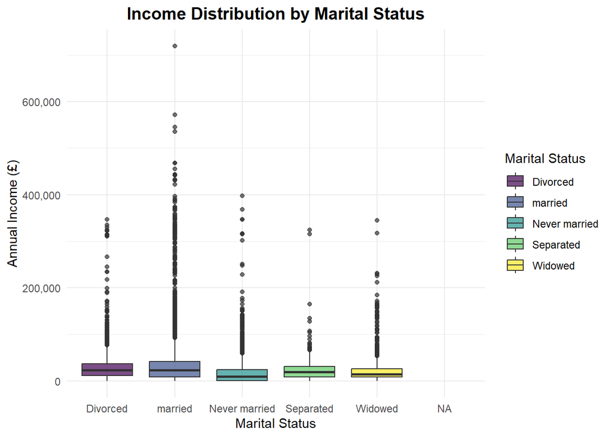

```r
ggplot(census_data, aes(x = Mar_Stat, y = INC, fill = Mar_Stat)) +
  geom_boxplot(alpha = 0.7) +
  scale_y_continuous(labels = scales::comma_format()) +
  scale_fill_viridis_d(name = "Marital Status") +
  labs(title = "Income Distribution by Marital Status",
       x = "Marital Status",
       y = "Annual Income (£)") +
  theme_minimal() +
  theme(plot.title = element_text(hjust = 0.5, size = 14, face = "bold"))
```

## 1.4 SUMMARY STATISTICS OF INCOME BY MARITAL STATUS

Calculating the mean, median,and count of income for each marital status, proving insights into variability within the group.

```r
census_data |>
  group_by(Mar_Stat) |>
  summarise(
    mean_income = mean(INC, na.rm = TRUE),
    median_income = median(INC, na.rm = TRUE),
    count = n()
  ) |>
  kable(caption = "Income Statistics by Marital Status") |>
  kable_styling(bootstrap_options = c("striped", "hover"))
```

Income Statistics by Marital Status

| Mar_Stat | mean_income | median_income | count |
| --- | --- | --- | --- |
| Divorced | 29856.19 | 23000 | 2177 |
| Never married | 16402.50 | 9000 | 5606 |
| Separated | 24257.15 | 19200 | 435 |
| Widowed | 22250.66 | 14010 | 1405 |
| married | 33646.31 | 23000 | 11643 |
| NA | NaN | NA | 6144 |

## 1.5 Marital Status Distribution by Ethnicity

It shows how marital status varies by ethnicity i.e calculating marital status percentage by ethnicity

```r
census_data |>
  group_by(Eth, Mar_Stat) |>
  summarise(count = n(), .groups = "drop") |>
  group_by(Eth) |>
  mutate(percentage = (count / sum(count)) * 100) |>
  arrange(desc(percentage)) |>
  kable(caption = "Marital Status Percentage by Ethnicity") |>
  kable_styling(bootstrap_options = c("striped", "hover"))
```

Marital Status Percentage by Ethnicity

| Eth | Mar_Stat | count | percentage |
| --- | --- | --- | --- |
| Hispanic | married | 443 | 47.3290598 |
| White | married | 8822 | 46.6057372 |
| Other | NA | 311 | 36.4595545 |
| Asian | married | 1272 | 35.8612912 |
| Asian | NA | 1094 | 30.8429659 |
| Black | Never married | 909 | 28.9030207 |
| Other | married | 242 | 28.3704572 |
| Black | married | 864 | 27.4721781 |
| Black | NA | 798 | 25.3736089 |
| Other | Never married | 203 | 23.7983587 |
| Asian | Never married | 841 | 23.7101776 |
| Hispanic | Never married | 213 | 22.7564103 |
| Hispanic | NA | 203 | 21.6880342 |
| White | NA | 3738 | 19.7474774 |
| White | Never married | 3440 | 18.1731734 |
| Black | Divorced | 287 | 9.1255962 |
| White | Divorced | 1622 | 8.5688626 |
| Other | Divorced | 51 | 5.9788980 |
| Black | Widowed | 181 | 5.7551669 |
| White | Widowed | 1084 | 5.7266628 |
| Asian | Divorced | 185 | 5.2156752 |
| Hispanic | Widowed | 39 | 4.1666667 |
| Hispanic | Divorced | 32 | 3.4188034 |
| Black | Separated | 106 | 3.3704293 |
| Other | Widowed | 27 | 3.1652989 |
| Asian | Separated | 81 | 2.2836200 |
| Other | Separated | 19 | 2.2274326 |
| Asian | Widowed | 74 | 2.0862701 |
| White | Separated | 223 | 1.1780865 |
| Hispanic | Separated | 6 | 0.6410256 |

## 1.6 VISUALIZING MARITAL STATUS DISTRO BY ETHNICITY

This visualizes the distribution of marital status by ethnicity usin the bar plot .

it showed the propotion of each marital status between all the ethnic groups

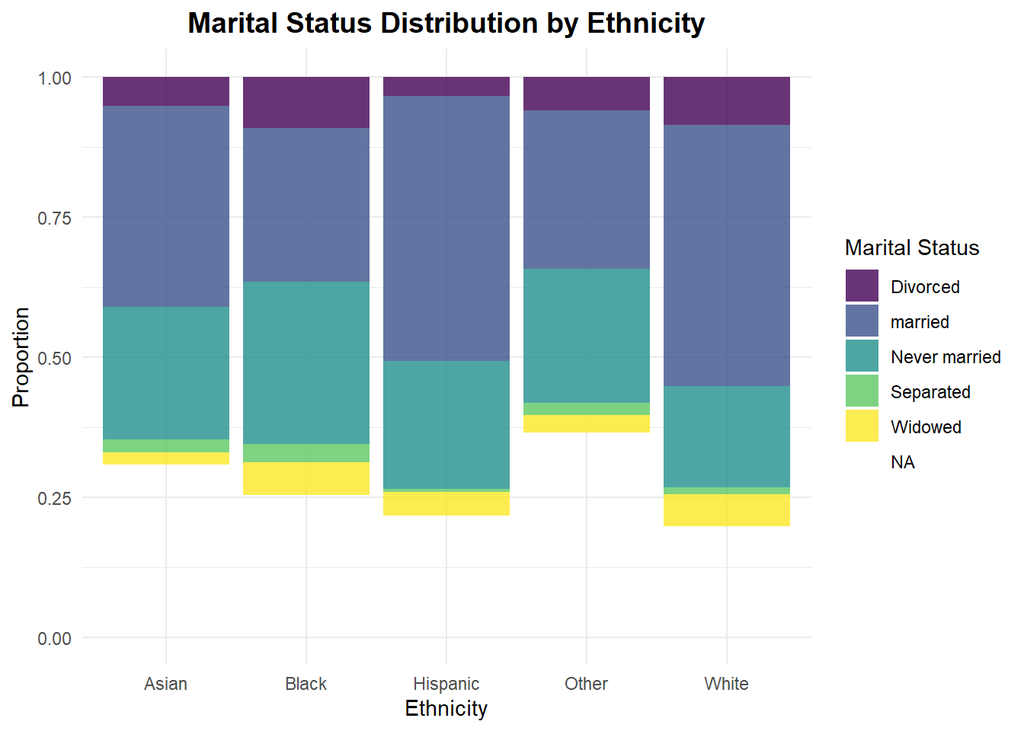

```r
ggplot(census_data, aes(x = Eth, fill = Mar_Stat)) +
  geom_bar(position = "fill", alpha = 0.8) +
  scale_fill_viridis_d(name = "Marital Status") +
  labs(title = "Marital Status Distribution by Ethnicity",
       x = "Ethnicity",
       y = "Proportion") +
  theme_minimal() +
  theme(plot.title = element_text(hjust = 0.5, size = 14, face = "bold"))
```

## 1.7 VISUALIZING INCOME,ETHNICITY AND MARITAL STATUS

This visualizes the relationship between income ,ethnicity and marital status using a box plot. hence combining all together

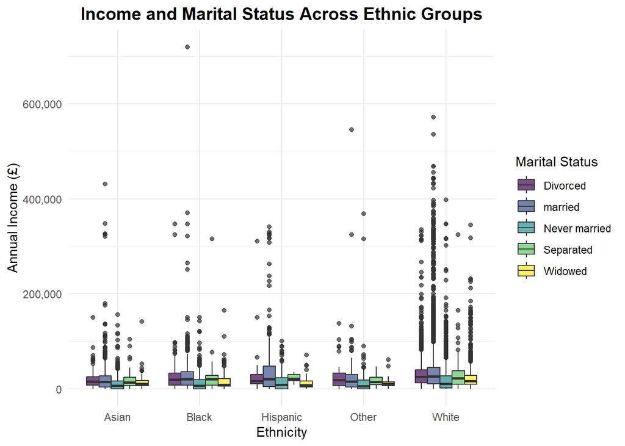

```r
ggplot(census_data, aes(x = Eth, y = INC, fill = Mar_Stat)) +
  geom_boxplot(alpha = 0.7, position = position_dodge(width = 0.75)) +
  scale_y_continuous(labels = scales::comma_format()) +
  scale_fill_viridis_d(name = "Marital Status") +
  labs(title = "Income and Marital Status Across Ethnic Groups",
       x = "Ethnicity",
       y = "Annual Income (£)") +
  theme_minimal() +
  theme(plot.title = element_text(hjust = 0.5, size = 14, face = "bold"))
```

## 1.8 CONCLUSION

*Married individuals tended to have higher incomes than single individuals across all ethnic groups. This difference in income levels may suggest economic advantages associated with marriage, such as combined household income.

*Some ethnic groups had higher proportions of specific marital statuses,some ethnicities showed a higher percentage of married individuals, while others had more single or separated individuals. These variation might indicate the cultural or social factors influencing marital status distributions within ethnic groups.

## 1.9 LIMITATION

- Missing income data for 6,173 observations
- Binary gender classification
- Simplified housing classification
- Unavailability of employment type distinction “not married” should have been denoted with “single”
- Inaccurate binary gender classifications ,no geographical location ,work experience. This would have provided more understanding of income disparities.

## 1.10 REFRENCES

* Karney, Benjamin R. 2021. “Socioeconomic Status and Intimate Relationships.” Annual Review of Psychology 72 (1): 391-414. https://doi.org/10.1146/annurev-psych-051920-013658.

* Wickham, Hadley. 2014. “Tidy Data.” Journal of Statistical Software 59 (10). https://doi.org/10.18637/jss.v059.i10.[@wickham2014]

_* Wickham, Hadley, Mara Averick, Jennifer Bryan, Winston Chang, Lucy D’Agostino McGowan, Romain François, Garrett Grolemund, et al. 2019. “Welcome to the Tidyverse” 4: 1686. https://doi.org/10.21105/ioss.01686._

_*2021 English Household Census Data_

_* Office for National Statistics (2021)_

_* R Core Team (2023). R: A Language and Environment for Statistical Computing_

_ * Brown, M. and Smith, J. (2021) ‘Marriage, Income, and Economic Stability: An Analysis’, Social Economics Journal, 28(2), pp. 78-91._